# Exercise 4 — Aggregated Data and Global Spatial Autocorrelation

BSTA 374 · 17.5 points · Due Wednesday, October 14, 2026, 11:59 pm

Author

Maggie Sobaszek · Lehigh University

Published

October 14, 2026

## What this exercise is

Exercises 1–3 ran on data that shipped inside an R package. This one does not. You will work with **real surveillance data** — COVID-19 deaths in the 67 counties of Pennsylvania — and assemble the analysis dataset yourself, the way you would in a health department: a table of counts from one source, county boundaries from another, and a join between them that has to be checked rather than trusted.

From there the exercise follows the sequence of the last two weeks:

1. join and project the data;
2. compute crude rates, **expected counts**, and the **standardized mortality ratio (SMR)**;
3. map the SMR honestly — which, for a ratio, is not the same as mapping a rate;
4. build a spatial weights matrix and ask, with **global Moran’s I**, whether the SMRs are spatially structured or could plausibly be arranged at random.

It is worth 17.5 points and carries more weight than the first two exercises. Start early: Part A is where most of the unexpected problems will be.

**ImportantSubmission**

Render the exercise as a page of your course site and push it to GitHub, as for Exercises 2 and 3. Then submit to Course Site:

- `LASTNAME_FI_Exercise4.qmd` — the source
- the URL of the rendered page on your GitHub Pages site

Example: `DELMELLE_EM_Exercise4.qmd`. Put your name in the document header.

**Due Wednesday, October 14, 2026 at 11:59 pm.** Late work loses 20% per day unless you arrange something with me in advance.

**WarningReproducibility is graded**

Restart R and render from a clean session before you submit. The CSV must be in your repository (put it in a `data/` folder) and be read with a **relative path** — `read_csv("data/...")`, never `C:/Users/...` — or the document will not render on my machine.

## The data

**Counts.** `pa_covid_deaths_2020.csv` is posted on Course Site. It is a subset of the **Johns Hopkins University CSSE COVID-19 Data Repository** (`time_series_covid19_deaths_US.csv`), the source behind the JHU dashboard that was the most widely used COVID-19 tracker in the United States until the project stopped updating in March 2023. The repository compiles counts reported by state health departments — here, the Pennsylvania Department of Health — and attributes deaths to the county of residence.

| Column | Meaning |
| --- | --- |
| `UID`, `FIPS` | JHU identifier; county FIPS code |
| `Admin2` | County name |
| `Province_State` | State |
| `Population` | County population (U.S. Census Bureau 2019 estimate, as carried in the JHU file) |
| `deaths_2020` | Cumulative COVID-19 deaths reported through December 31, 2020 |

Cite the source in your document as: Dong, E., Du, H., & Gardner, L. (2020). An interactive web-based dashboard to track COVID-19 in real time. *The Lancet Infectious Diseases, 20*(5), 533–534, together with the repository URL: https://github.com/CSSEGISandData/COVID-19.

**Boundaries.** County polygons come from the U.S. Census Bureau’s **cartographic boundary files**, downloaded inside your document with the `tigris` package. Install it once, in the console — `install.packages(c("tigris", "ggrepel"))` — not inside the document.

**NoteWhy 2020**

Calendar year 2020 is the first pandemic year and the period before vaccines were available. Treat the population as the population at risk for one year.

```r
library(sf)
library(dplyr)
library(readr)
library(ggplot2)
library(classInt)
library(patchwork)        #maps side by side
library(leaflet)
library(spdep)
library(ggrepel)            # non-overlapping labels
library(tigris)
options(tigris_use_cache = TRUE)   # download once, then reuse

covid <- read_csv("data/pa_covid_deaths_2020.csv")
pa    <- counties(state = "PA", cb = TRUE, year = 2020)
```

## Part A — Assemble the dataset (3 points)

1. Inspect both objects. How many rows does `covid` have, and how many polygons does `pa` have? The two numbers differ. Find the rows responsible and say in one sentence what they are and why they cannot be mapped.

2. Identify the column in each object that identifies a county. Show what the values look like in each, and say why they will not match as they stand. **In ‘covid’, FIPS identifies counties, and is a number. In ‘pa’ it is the column ‘GEOID’ that identifies counties and its values are characters. In ‘covid’, it looks like 42001, but in ‘pa’ it is “42001”. They won’t join because they need to be the same type of input.**
3. Create a join key in `covid` that matches the one in `pa`, then **join the counts onto the polygons**. Show, with code, that every one of the 67 counties received a count — do not just look at the map.
4. In two or three sentences: why join the table onto the polygons (`left_join(pa, covid)`) rather than the other way around, and what would an **inner** join have hidden from you if the key had been only partly wrong?

**Tip**

Run the obvious join first, `left_join(pa, covid, by = c("GEOID" = "FIPS"))`, and read the error message carefully. It tells you exactly what is wrong. A FIPS code is an **identifier**, not a number: `42001` and `42001.0` are the same number but not the same identifier, and a county such as `01001` in Alabama would lose its leading zero.

### Starting code

```r
# A1
covid
```

```
# A tibble: 69 × 6
        UID  FIPS Admin2    Province_State Population deaths_2020
      <dbl> <dbl> <chr>     <chr>               <dbl>       <dbl>
 1 84042001 42001 Adams     Pennsylvania       103009          88
 2 84042003 42003 Allegheny Pennsylvania      1216045        1009
 3 84042005 42005 Armstrong Pennsylvania        64735          69
 4 84042007 42007 Beaver    Pennsylvania       163929         252
 5 84042009 42009 Bedford   Pennsylvania        47888          94
 6 84042011 42011 Berks     Pennsylvania       421164         565
 7 84042013 42013 Blair     Pennsylvania       121829         175
 8 84042015 42015 Bradford  Pennsylvania        60323          56
 9 84042017 42017 Bucks     Pennsylvania       628270         904
10 84042019 42019 Butler    Pennsylvania       187853         194
# ℹ 59 more rows
```

```r
pa
```

```
Simple feature collection with 67 features and 12 fields
Geometry type: MULTIPOLYGON
Dimension:     XY
Bounding box:  xmin: -80.51989 ymin: 39.7198 xmax: -74.68952 ymax: 42.26986
Geodetic CRS:  NAD83
First 10 features:
    STATEFP COUNTYFP COUNTYNS       AFFGEOID GEOID           NAME
139      42      033 01209175 0500000US42033 42033     Clearfield
140      42      125 01209190 0500000US42125 42125     Washington
141      42      031 01210234 0500000US42031 42031        Clarion
142      42      097 01209186 0500000US42097 42097 Northumberland
143      42      061 01213672 0500000US42061 42061     Huntingdon
499      42      101 01209187 0500000US42101 42101   Philadelphia
500      42      049 01209178 0500000US42049 42049           Erie
501      42      091 01213680 0500000US42091 42091     Montgomery
```

[output cut: 24 more lines]

```r
nrow(covid); nrow(pa)
```

```
[1] 69
```

```
[1] 67
```

```r
# rows in the table with no polygon to go to (names are good enough to look)
anti_join(covid, st_drop_geometry(pa), by = c("Admin2" = "NAME"))
```

```
# A tibble: 2 × 6
       UID  FIPS Admin2     Province_State Population deaths_2020
     <dbl> <dbl> <chr>      <chr>               <dbl>       <dbl>
1 84080042 80042 Out of PA  Pennsylvania            0           0
2 84090042 90042 Unassigned Pennsylvania            0           0
```

```r
# A2 -- what type is each key?
str(covid$FIPS)
```

```
 num [1:69] 42001 42003 42005 42007 42009 ...
```

```r
str(pa$GEOID)
```

```
 chr [1:67] "42033" "42125" "42031" "42097" "42061" "42101" "42049" "42091" ...
```

```r
# A3 -- a five-character, zero-padded text key
covid <- covid |>
  mutate(GEOID = sprintf("%05d", as.integer(FIPS)))

pa_covid <- pa |>
  left_join(covid, by = "GEOID")

# prove the join worked
sum(is.na(pa_covid$deaths_2020))
```

```
[1] 0
```

```r
nrow(pa_covid)
```

```
[1] 67
```

## Part B — Coordinate reference system (1.5 points)

1. What CRS do the Census boundaries arrive in? Geographic or projected? **The boundaries are geographic.**
2. Transform `pa_covid` to a **projected** CRS appropriate for the whole state, and state its EPSG code. Pennsylvania is split between two State Plane zones (North and South) and two UTM zones, so the obvious choices each cover only part of the state — say what you chose and why it is acceptable for a statewide map.

**I would transform into EPSG 5070 because it covers contiguous states, is intended for data analysis, and is in meters. Unlike State Plane Coordinate System, it doesn’t split Pennsylvania into two zones.**

3. One sentence: which of the operations in this exercise actually depend on the projection, and which do not? **The projection affects how the counties appear on the map and any distance-based spatial calculations, but it doesnt affect joining the data, calculating mortality rates or SMRs, or Moran’s I when using the same county neighbors.**

### Starting code

```r
st_crs(pa_covid)$input
```

```
[1] "NAD83"
```

```r
st_is_longlat(pa_covid)
```

```
[1] TRUE
```

```r
st_crs(pa_covid)
```

```
Coordinate Reference System:
  User input: NAD83
  wkt:
GEOGCRS["NAD83",
    DATUM["North American Datum 1983",
        ELLIPSOID["GRS 1980",6378137,298.257222101,
            LENGTHUNIT["metre",1]]],
    PRIMEM["Greenwich",0,
        ANGLEUNIT["degree",0.0174532925199433]],
    CS[ellipsoidal,2],
        AXIS["latitude",north,
            ORDER[1],
            ANGLEUNIT["degree",0.0174532925199433]],
        AXIS["longitude",east,
            ORDER[2],
            ANGLEUNIT["degree",0.0174532925199433]],
    ID["EPSG",4269]]
```

```r
pa_covid <- st_transform(pa_covid, 5070)
st_is_longlat(pa_covid)
```

```
[1] FALSE
```

## Part C — Counts, rates, expected counts, and the SMR (4.5 points)

1. Compute the **crude COVID-19 mortality rate per 100,000** for 2020 in every county. Report the three highest and three lowest. **The three highest counties are Mifflin, Northumberland, and Bedford. The lowest are Wayne, Forest, and Greene.**
2. Make two quick static maps with `ggplot2`, placed side by side: the **number of deaths** as **proportional symbols**, and the **crude rate** as a choropleth with a sequential, colour-blind-safe palette. Both need a legend title with units. In two or three sentences: why is a count shown with symbols rather than a choropleth, which counties stand out on each map, and why do the two maps tell different stories? **For the map that shows counts of death, Allegheny county and counties in Southeastern PA, around Philadelphia county, appear to have a very large amount of deaths. But in the choropleth, it’s Mifflin, Northumberland, and Bedford that have the highest rates. Because counties with larger populations are likely to higher have cases, these counties look to have worse COVID cases because their populations are higher. Looking at crude rate allows us to see the amount of cases in comparison to their populations.**
3. Compute the **statewide reference rate** $r = \sum_i O_i / \sum_i P_i$, and from it the **expected count** in each county, $E_i= r \times P_i$. Show that $\sum_i E_i = \sum_i O_i$ and explain in one sentence why this must be so. **Total expected deaths need to equal total observed deaths because expected counts are calculated using the statewide mortality rate, which is based on the total observed deaths divided by the total population.**
4. Compute the **SMR**, $O_i / E_i$.
   1. Interpret the SMR of one county of your choice in a full sentence a county commissioner could understand.

**In Clinton County, the SMR is 0.50, which is 50% less than expected and because the confidence interval (0.32 and 0.74) and does not cross 1, this is significant and did not happen by chance so Clinton County did something right in terms of handling COVID-19.**

```
b. Divide each county's crude rate by the statewide rate and compare with the
   SMR. Explain why they are identical here, and what $E_i$ would have to
   take into account for the two to differ. *(This is where we are going
   later in the semester.)*
```

**There the same because we’re essentially using the same formula for both, using observed deaths divided by county population for crude rate and for SMR using observed deaths divided by expected deaths. The expected deaths are calculated using only the statewide mortality rate and the county’s total population. These could be different if we took into account different things like age, socioeconomic status, or race.**

5. Compute an exact **95% confidence interval** for every SMR (formula below). Compare the intervals for the two or three counties with the **fewest** deaths with those of the counties with the **highest** SMRs. In three or four sentences: what does this tell you about the extreme values on an SMR map?

**NoteWhere the confidence interval comes from**

Treat the expected count $E$ as a fixed constant and the observed count as Poisson, $O \sim \text{Poisson}(\mu)$ with $\mu = \text{SMR} \times E$. We first find an exact 95% interval for $\mu$ and then divide both ends by $E$.

The lower bound $\mu_L$ is the value of $\mu$ at which observing $O$ **or more** deaths has probability 0.025; the upper bound $\mu_U$ is the value at which observing $O$ **or fewer** has probability 0.025. Because of the link between the Poisson and chi-square distributions, both have a closed form:

$$\mu_L = \tfrac{1}{2}\,\chi^2_{0.025,\;2O}, \qquad
\mu_U = \tfrac{1}{2}\,\chi^2_{0.975,\;2(O+1)} .$$

Dividing by $E$ gives the interval for the SMR:

$$\left[\ \frac{\chi^2_{0.025,\,2O}}{2E}\ ,\ \ \frac{\chi^2_{0.975,\,2(O+1)}}{2E}\ \right].$$

The upper bound uses $2(O+1)$ degrees of freedom and the lower bound $2O$; that asymmetry is what keeps the interval exact when counts are small. When $O = 0$ the lower bound is 0.

**Worked example.** A county with $O = 4$ and $E = 5.57$ has SMR $= 0.72$ and

```r
qchisq(0.025, 2 * 4)       / (2 * 5.57)   # 0.20
qchisq(0.975, 2 * (4 + 1)) / (2 * 5.57)   # 1.84
poisson.test(4, T = 5.57)$conf.int        # same interval: E acts as the "time base"
```

The familiar normal approximation, $\text{SMR} \times \exp(\pm 1.96/\sqrt{O})$, works for counties with many deaths but breaks down for the smallest ones — which are exactly the counties this question is about — and is undefined when $O = 0$.

### Starting code

```r
# C1
pa_covid <- pa_covid |>
  mutate(crude_rate = 100000 * pa_covid$deaths_2020 / pa_covid$Population)

pa_covid |>
  slice_max(crude_rate, n = 3) |>
  st_drop_geometry() |>
  select(NAME, crude_rate)
```

```
            NAME crude_rate
1        Mifflin   257.9219
2 Northumberland   248.7809
3        Bedford   196.2913
```

```r
pa_covid |>
  slice_min(crude_rate, n = 3) |>
  st_drop_geometry() |>
  select(NAME, crude_rate)
```

```
    NAME crude_rate
1  Wayne   35.04605
2 Forest   41.39644
3 Greene   41.39872
```

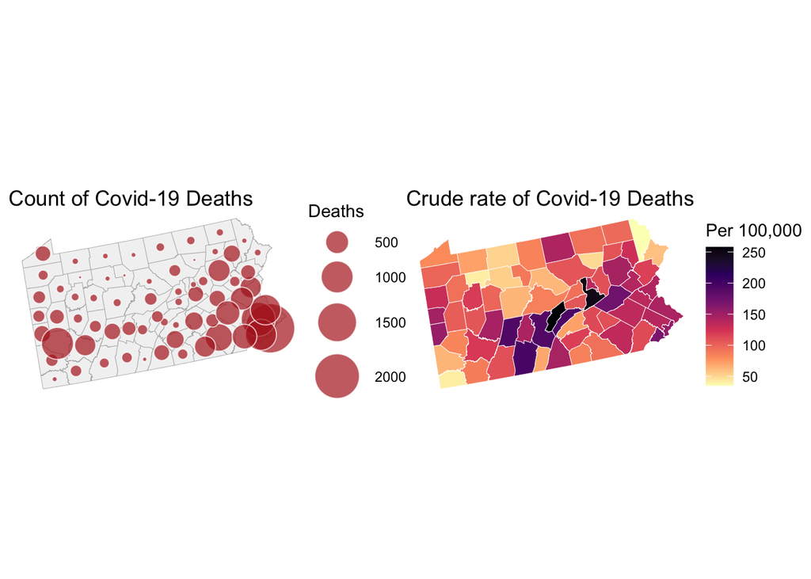

```r
# C2 -- counts as proportional symbols
pts <- st_point_on_surface(pa_covid)        # one point inside each county
p_count <- ggplot() +
  geom_sf(data = pa_covid, fill = "grey95", colour = "grey70", linewidth = 0.15) +
  geom_sf(data = pts, aes(size = deaths_2020),
          shape = 21, fill = "firebrick", colour = "white", alpha = 0.7) +
  scale_size_area(max_size = 14, name = "Deaths") +   # area proportional to count
  labs(title = "Count of Covid-19 Deaths") +
  theme_void()

# rates as a choropleth

p_rate <- ggplot(pa_covid) +
  geom_sf(aes(fill = crude_rate), colour = "white", linewidth = 0.15) +
  scale_fill_viridis_c(option = "magma", direction = -1, name = "Per 100,000") +
  labs(title = "Crude rate of Covid-19 Deaths") +
  theme_void()

p_count + p_rate
```

```r
# C3 -- one number for the whole state
r <- sum(pa_covid$deaths_2020) / sum(pa_covid$Population)
r * 100000                         # per 100,000
```

```
[1] 125.2149
```

```r
pa_covid <- pa_covid |>
  mutate(E = r * pa_covid$Population)

sum(pa_covid$E); sum(pa_covid$deaths_2020)
```

```
[1] 16030
```

```
[1] 16030
```

```r
# C4
pa_covid <- pa_covid |>
  mutate(SMR = pa_covid$deaths_2020 / E)
```

```r
# C5 -- exact Poisson interval
pa_covid <- pa_covid |>
  mutate(SMR_lo = qchisq(0.025, 2 * deaths_2020) / (2 * E),
         SMR_hi = qchisq(0.975, 2 * (deaths_2020 + 1)) / (2 * E))

pa_covid |>
  st_drop_geometry() |>
  arrange(deaths_2020) |>
  select(NAME, Population, deaths_2020, E, SMR, SMR_lo, SMR_hi) |>
  head(5)
```

```
      NAME Population deaths_2020         E       SMR     SMR_lo    SMR_hi
1 Sullivan       6066           3  7.595537 0.3949688 0.08145206 1.1542664
2   Forest       7247           3  9.074325 0.3306031 0.06817831 0.9661626
3  Cameron       4447           4  5.568307 0.7183511 0.19572651 1.8392642
4   Fulton      14530          10 18.193728 0.5496400 0.26357373 1.0108075
5   Potter      16526          14 20.693017 0.6765567 0.36987986 1.1351472
```

## Part D — Mapping a ratio (3.5 points)

In Exercise 1 a sequential palette was the right choice for a rate. An SMR is different: it is a ratio with a **meaningful reference value of 1**, and it is **multiplicative** — an SMR of 2 is as far above expected as 0.5 is below it.

1. Map the SMR as an interactive **`leaflet`** map with a **diverging palette centred on 1** and **class breaks you set yourself**. Choose breaks that are symmetric on the ratio scale, and make the class around 1 read as “about as expected”. Justify the palette and the breaks in three or four sentences.

**I chose a diverging color palette because an SMR of 1 represents the expected number of deaths, with values above and below 1 showing higher or lower mortality. I used red for values above 1 because higher than expected mortality is a negative health outcome, blue for values below 1, and a neutral color for values around 1 since those are close to what was expected. The breaks are symmetric on a ratio scale, so values like 0.67 and 1.5 are equally different from 1. This makes it easier to see which counties had higher or lower mortality compared to the statewide rate.**

2. Your SMR map meets the standards from Exercise 1 — legend title with units or meaning, thin boundaries, colour-blind-safe palette — and in addition:
   - a **source line** on the map naming the data and the year;
   - a **popup** for each county giving the observed and expected deaths, the SMR, and its 95% interval from C5. This is what makes an interactive map worth having: the reader can check how much evidence stands behind a colour.

**Warning`leaflet` wants longitude and latitude**

Web maps are drawn on a Web Mercator basemap and expect coordinates in **EPSG:4326**. Your `pa_covid` is now projected (Part B), so give `leaflet` a transformed **copy**, `st_transform(pa_covid, 4326)`, and keep the projected object for everything else. Handing it projected coordinates is the most common reason for a blank `leaflet` map.

**TipWhat earns full marks here**

Breaks that follow from what an SMR *means*, not from the distribution of the values. A student who can explain why 0.67 and 1.5 belong in the same break set understands the variable.

### Starting code

```r
pa_wgs <- st_transform(pa_covid, 4326)      # leaflet needs lon/lat

classIntervals(pa_covid$SMR, n = 5, style = "quantile")
```

```
style: quantile
  one of 720,720 possible partitions of this variable into 5 classes
[0.2798872,0.6489044) [0.6489044,0.8055186) [0.8055186,0.9632431)
                   14                    13                    13
   [0.9632431,1.1571)     [1.1571,2.059834]
                   13                    14
```

```r
classIntervals(pa_covid$SMR, n = 5, style = "fisher")
```

```
style: fisher
  one of 720,720 possible partitions of this variable into 5 classes
[0.2798872,0.6080231) [0.6080231,0.9619931)  [0.9619931,1.287647)
                   13                    27                    19
  [1.287647,1.777233)   [1.777233,2.059834]
                    6                     2
```

```r
classIntervals(pa_covid$SMR, n = 5, style = "sd")
```

```
style: sd
  one of 8,936,928 possible partitions of this variable into 6 classes
[0.1889618,0.5546114)  [0.5546114,0.920261)   [0.920261,1.285911)
                   11                    26                    22
   [1.285911,1.65156)     [1.65156,2.01721)    [2.01721,2.382859]
                    6                     1                     1
```

```r
classIntervals(pa_covid$SMR, n = 5, style = "equal")
```

```
style: equal
  one of 720,720 possible partitions of this variable into 5 classes
[0.2798872,0.6358764) [0.6358764,0.9918657)  [0.9918657,1.347855)
                   13                    28                    19
  [1.347855,1.703844)   [1.703844,2.059834]
                    5                     2
```

```r
# D1 -- breaks symmetric on the ratio scale: 1/x and x
brks <- c(0, 0.5, 0.67, 0.9, 1.1, 1.5, 2, Inf)

pal <- colorBin("RdBu", domain = pa_wgs$SMR, bins = brks,
                reverse = TRUE)             # red = high

leaflet(pa_wgs) |>
  addTiles() |>                               # OpenStreetMap basemap
  addPolygons(
    fillColor = ~pal(SMR), fillOpacity = 0.8,
    color = "white", weight = 0.6,          # thin boundaries
    label = ~NAME,                          # shown on hover
    popup = ~sprintf("<b>%s County</b><br>Observed: %d<br>Expected: %.1f<br>SMR: %.2f (95%% CI %.2f–%.2f)",
                     NAME, deaths_2020, E, SMR, SMR_lo, SMR_hi),
    highlightOptions = highlightOptions(weight = 2, color = "black",
                                        bringToFront = TRUE)
  ) |>
  addLegend(pal = pal, values = ~SMR, opacity = 0.8,
            title = "SMR for COVID-19", labFormat = labelFormat(digits = 2)) |>
  addControl("Dong, E., Du, H., & Gardner, L. (2020). An interactive web-based dashboard to track COVID-19 in real time. *The Lancet Infectious Diseases, 20*(5), 533--534, together with the repository URL: https://github.com/CSSEGISandData/COVID-19", position = "bottomleft")   # source line
```

[interactive chart not shown]

**Note**

A `leaflet` map is an HTML widget: it appears in the rendered page on your GitHub Pages site, which is where I grade it. It will not appear in a PDF.

## Part E — Spatial weights and global Moran’s I (4 points)

1. Build a **queen contiguity** neighbour list. Report the average number of neighbours, the smallest and largest, and whether any county has none.

**The average number of neighbors is 5.1, the most amount of neighbors is 9, and the least amount is 2. There are no counties without neighbors.**

2. Convert it to **row-standardized** spatial weights. One sentence: what does row standardization do to a county’s neighbours, and what does the spatial lag of the SMR then represent?

**Each county’s neighbors gets equal weight and the weights sum to 1, so the neighbors value is their average and the spatial lag of a county is the average SMR of its neighbors.**

3. Compute **global Moran’s I** for the SMR by permutation with `moran.mc()` (999 simulations; set a seed), and plot the permutation distribution with the observed value marked. Report $I$, its expectation under the null hypothesis, $-1/(n-1)$, and the $p$-value. In three or four sentences: what exactly is the null hypothesis, how does the simulation test it, and is there a spatial signal in the SMRs?

**The null hypothesis is that the SMRs are random, there’s no relationship between a county’s SMR and their neighboring counties SMR. The simulation randomly generates SMRs 999 times and compares Moran’s I values to observed value. Observed Moran’s I was 0.29 and the expected value was -0.02, while the p-value was 0.001. There’s a positive correlation, showing that counties that have similar SMRs are close to one another.**

4. Draw the **Moran scatterplot**, with every county labelled and coloured by quadrant. Name two or three counties in the high–high quadrant and two or three in the low–low quadrant, say in one sentence what the slope of the fitted line is, and say in one sentence what Moran’s I does **not** tell you about these counties.

**Bedford, Huntingdown, and Cambria are all in the high-high quadrant and Clearfield, Allegheny, and Potter are all in the low-low quadrant. The slope of the fitted line is positive, which shows that generally, counties with higher SMRs also have neighbors with higher SMRs. Moran’s I doesn’t tell which counties have clusters that are statistically significant or why the patterns happen.**

### Starting code

```r
# E1
nb <- poly2nb(pa_covid, queen = TRUE)
summary(nb)
```

```
Neighbour list object:
Number of regions: 67
Number of nonzero links: 342
Percentage nonzero weights: 7.618623
Average number of links: 5.104478
Link number distribution:

 2  3  4  5  6  7  8  9
 3  7 14 18 15  3  5  2
3 least connected regions:
7 21 52 with 2 links
2 most connected regions:
4 67 with 9 links
```

```r
# E2

lw <- nb2listw(nb, style = "W")

lw$weights
```

[output not shown]

[output cut: 156 more lines]

[output not shown]

```r
# E3 -- shuffle the SMRs across counties 999 times
set.seed(374)
mc <- moran.mc(pa_covid$SMR, lw, nsim = 999)
mc
```

```
    Monte-Carlo simulation of Moran I

data:  pa_covid$SMR
weights: lw
number of simulations + 1: 1000

statistic = 0.28933, observed rank = 1000, p-value = 0.001
alternative hypothesis: greater
```

```r
-1 / (nrow(pa_covid) - 1)          # expectation under the null
```

```
[1] -0.01515152
```

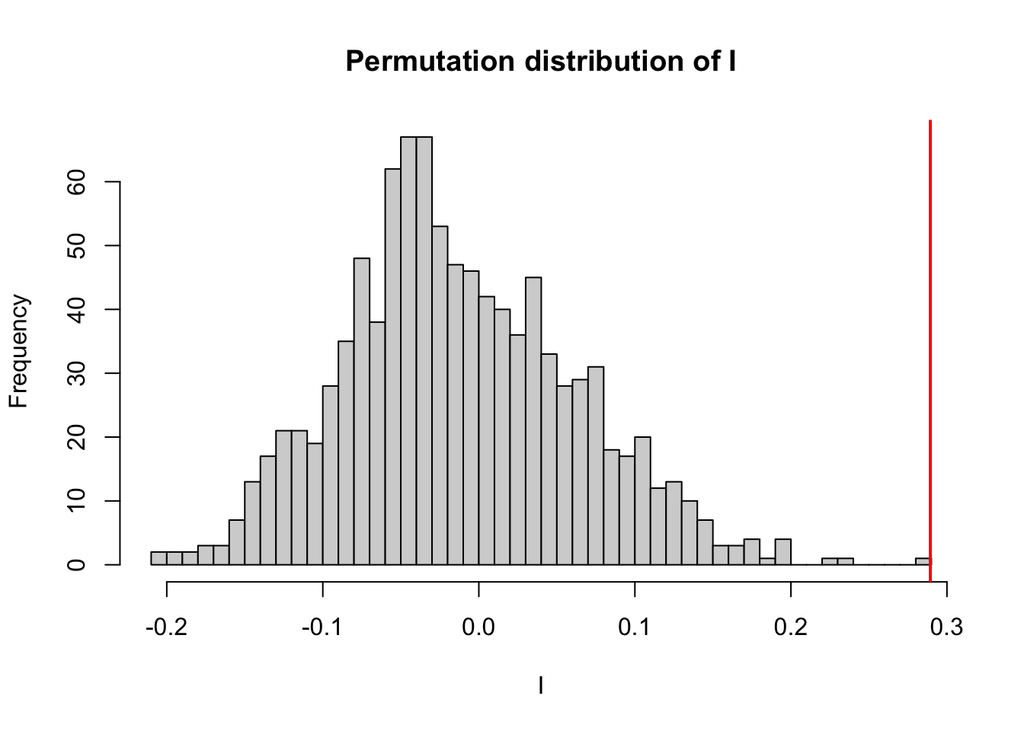

```r
##This is the expected value of Moran's I under random spatial arrangement, not exactly zero.

hist(mc$res, breaks = 40, main = "Permutation distribution of I", xlab = "I")
abline(v = mc$statistic, col = "red", lwd = 2)
```

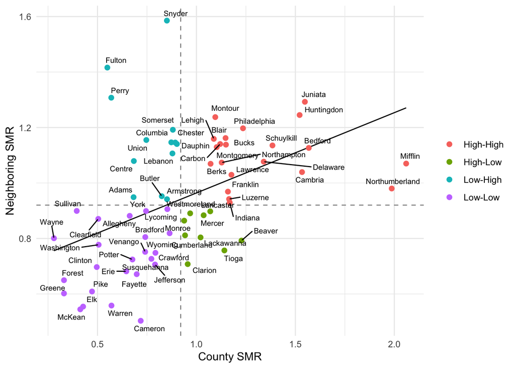

```r
# E4 -- moran.plot() labels only influential points; build it in ggplot2
mp_df <- pa_covid |>
  st_drop_geometry() |>
  mutate(lag_SMR = lag.listw(lw, SMR),          # mean SMR of neighbours
         quad = case_when(
           SMR >= mean(SMR) & lag_SMR >= mean(SMR) ~ "High-High",
           SMR <  mean(SMR) & lag_SMR <  mean(SMR) ~ "Low-Low",
           SMR >= mean(SMR) & lag_SMR <  mean(SMR) ~ "High-Low",
           TRUE                                    ~ "Low-High"))

ggplot(mp_df, aes(SMR, lag_SMR)) +
  geom_hline(yintercept = mean(mp_df$SMR), linetype = 2, colour = "grey60") +
  geom_vline(xintercept = mean(mp_df$SMR), linetype = 2, colour = "grey60") +
  geom_smooth(method = "lm", se = FALSE, colour = "black", linewidth = 0.5) +
  geom_point(aes(colour = quad), size = 2) +
  geom_text_repel(aes(label = NAME), size = 2.6, max.overlaps = Inf) +   # every county
  labs(x = "County SMR", y = "Neighboring SMR", colour = NULL) +
  theme_minimal()
```

```r
table(mp_df$quad)
```

```
High-High  High-Low  Low-High   Low-Low
       21         9        13        24
```

## Part F — Reproducibility and AI use (1 point)

1. The page renders from a clean session and is live on your GitHub Pages site.
2. End the document with an **AI use note**: which tools, what for, at which stage. Two or three sentences. **I used ChatGPT for part B, question 2, to understand which projection system to use and why. For part C, question 1, used ChatGPT to find top three highest and lowest. I also used ChatGPT for part E, question 4 to understand what Moran’s I doesn’t tell us.**

## Rubric

| Part | What is assessed | Points |
| --- | --- | --- |
| **A** | Mismatched rows found and explained; key built as text; join verified with code; left vs inner join explained | 3 |
| **B** | Correct projected CRS, stated and justified | 1.5 |
| **C** | Crude rates; count and rate maps compared; reference rate, expected counts and SMR correct; SMR interpreted; small-numbers argument made with intervals | 4.5 |
| **D** | Diverging leaflet map centred on 1 with defended breaks; standards, source line and popup | 3.5 |
| **E** | Weights built and described; Moran’s I by permutation, null hypothesis stated and interpreted; scatterplot read | 4 |
| **F** | Renders from a clean session; published; AI use note | 1 |
|  | **Total** | **17.5** |

Writing counts for roughly 10% of the mark within each part. A submission that is all code and no sentences cannot score above about 60%.

## Getting help

- Moraga §5.1–5.2 (expected counts and SMR) and §5.5 (neighbourhood matrices in `spdep`).
- The `spdep` vignette on neighbour objects: `vignette("nb", package = "spdep")`.
- `?tigris::counties` if the download fails; the same boundaries can be downloaded by hand from the Census Bureau’s cartographic boundary page.
- Office hours, or email me with the code and the exact error message. I am travelling on October 13; email is the fastest route that week.